# WGAN_breast_cancer

```python
import pandas as pd

import matplotlib

import matplotlib.pyplot as plt

from pandas.plotting import scatter_matrix

import numpy as np
```

```python
dataDF = pd.read_csv("cancer.csv")
dataDF.head()
```

|  | mean concave points | compactness error | concavity error | worst concavity | worst concave points | target |
| --- | --- | --- | --- | --- | --- | --- |
| 0 | 0.05397 | 0.01812 | 0.01951 | 0.21140 | 0.12510 | 1 |
| 1 | 0.04846 | 0.07471 | 0.11140 | 0.48960 | 0.13420 | 1 |
| 2 | 0.02416 | 0.02042 | 0.01062 | 0.08434 | 0.06528 | 1 |
| 3 | 0.01875 | 0.01443 | 0.01861 | 0.04158 | 0.03125 | 1 |
| 4 | 0.02738 | 0.02736 | 0.04804 | 0.20000 | 0.09127 | 1 |

There are two classes in the dataset and they've been labelled using the "target" attribute:

- class 0 - malignant tumor
- class 1 - benign tumor

This dataset was purposefully sampled in an unbalanced way, so that we have a substantially lower number of samples from class 0.

```python
from sklearn import preprocessing
columns = dataDF.columns
x = dataDF.values #returns a numpy array
min_max_scaler = preprocessing.MinMaxScaler()
x_scaled = min_max_scaler.fit_transform(x)
dataDF = pd.DataFrame(x_scaled)
dataDF.columns = columns
dataDF.head()
```

|  | mean concave points | compactness error | concavity error | worst concavity | worst concave points | target |
| --- | --- | --- | --- | --- | --- | --- |
| 0 | 0.366893 | 0.152360 | 0.049268 | 0.168850 | 0.463162 | 1.0 |
| 1 | 0.329436 | 0.695721 | 0.281313 | 0.391054 | 0.496853 | 1.0 |
| 2 | 0.164242 | 0.174444 | 0.026818 | 0.067364 | 0.241688 | 1.0 |
| 3 | 0.127464 | 0.116930 | 0.046995 | 0.033211 | 0.115698 | 1.0 |
| 4 | 0.186132 | 0.241080 | 0.121313 | 0.159744 | 0.337912 | 1.0 |

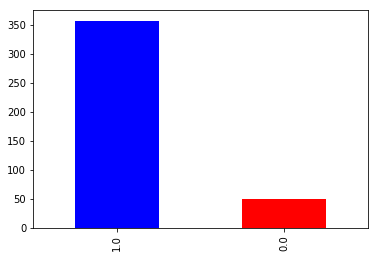

```python
fig, ax = plt.subplots()
dataDF["target"].value_counts().plot(ax=ax, kind="bar", color=["blue","red"])
plt.show()
```

Let's split the two classes in separate data frames.

```python
malDF = dataDF[dataDF["target"]==0]
benDF = dataDF[dataDF["target"]==1]
```

We can now plot the two classes using a colour-codded scatter plot.

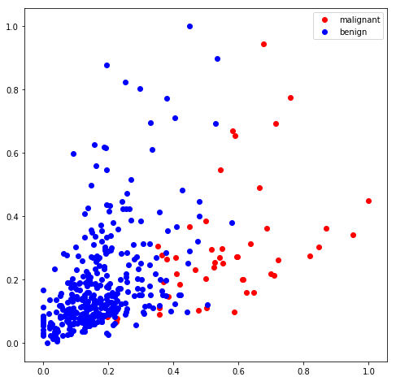

```python
colors = ["red", "blue"]

fig,ax = plt.subplots(figsize=(8,8))
ax.scatter(malDF.iloc[:,0], malDF.iloc[:,1], c="red", label="malignant")
ax.scatter(benDF.iloc[:,0], benDF.iloc[:,1], c="blue", label="benign")
ax.legend()
plt.show()
```

Next, we create a matrix plot to assess the relationship between all pairs of attributes. We also plot the histograms to inspect the distribution of all individual attributes.

```python
def plot_matrix(x, figsize=(10,10), labelsize=10):
    axarr = scatter_matrix(x, alpha=0.3, figsize=figsize,diagonal="hist")
    axarr[0,0].set_yticklabels(["0.0","0.05","0.10"])
    for j in range(len(axarr)):
        for i in range(len(axarr[0])):
            axarr[i,j].yaxis.label.set_size(labelsize)
            axarr[i,j].xaxis.label.set_size(labelsize)
    plt.draw()
```

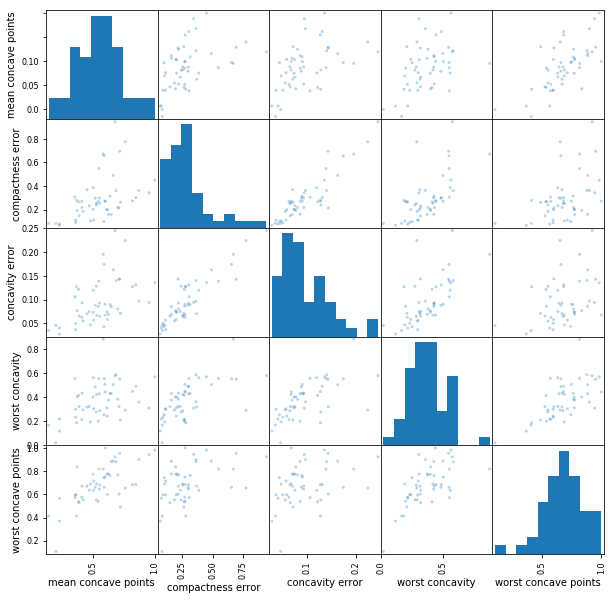

```python
plot_matrix(malDF.iloc[:,:-1])
```

We observe that some of the attributes appear positively skewed (e.g. compactness error, concavity error) and other appear normally distributed (e.g. worst concavity), although we don't have sufficient data to confidently support this observation.

## Generating data using WGAN

We start by defining a simple WGAN.

```python
import tensorflow as tf

from tensorflow.keras.layers import Dense

class Generator(tf.keras.Model):
    def __init__(self, n_inp, n_noise, n_hid=128):
        super().__init__()
        init = tf.keras.initializers.GlorotUniform
        self.input_layer = Dense(units=n_noise, kernel_initializer=init)
        self.hid_1 = Dense(units=n_hid, activation="tanh", kernel_initializer=init)
        self.output_layer = Dense(units=n_inp, activation="sigmoid", kernel_initializer=init)

    def call(self, inputs):
        x = self.input_layer(inputs)
        x = self.hid_1(x)
        return self.output_layer(x)


class Critic(tf.keras.Model):
    def __init__(self, n_inp, n_hid=128):
        super().__init__()
        init = tf.keras.initializers.GlorotUniform
        self.input_layer = Dense(units=n_inp, kernel_initializer=init)
        self.hid_1 = Dense(units=n_hid, activation="tanh", kernel_initializer=init)
        self.logits = Dense(units=1, activation=None, kernel_initializer=init)

    def call(self, inputs):
        x = self.input_layer(inputs)
        x = self.hid_1(x)
        return self.logits(x)


@tf.function
def train_step(real_data, gen, disc, noise_dim, generator_optimizer, discriminator_optimizer):
    batch_size = real_data.shape[0]

    noise = tf.random.normal([batch_size, noise_dim])

    with tf.GradientTape() as gen_tape, tf.GradientTape() as disc_tape:
        fake_data = gen(noise, training=True)

        real_output = disc(real_data, training=True)
        fake_output = disc(fake_data, training=True)

        disc_loss =   tf.reduce_mean(fake_output) - tf.reduce_mean(real_output)
        gen_loss  = - tf.reduce_mean(fake_output)

    wasserstein = tf.reduce_mean(real_output) - tf.reduce_mean(fake_output)

    gradients_of_generator = gen_tape.gradient(gen_loss, gen.trainable_variables)
    gradients_of_discriminator = disc_tape.gradient(disc_loss, disc.trainable_variables)

    generator_optimizer.apply_gradients(zip(gradients_of_generator, gen.trainable_variables))
    discriminator_optimizer.apply_gradients(zip(gradients_of_discriminator, disc.trainable_variables))

    tf.group(*(var.assign(tf.clip_by_value(var, -0.01, 0.01)) for var in disc.trainable_variables))

    return wasserstein
```

We set the training parameters. The network will be run for 200 epochs.

```python
BATCH_SIZE = 20

NOISE_DIM = 100

learning_rate = 0.0005

epochs = 200
```

```python
X = malDF.iloc[:,:-1].values.astype("float32")
n_inp = X.shape[1]
train_dataset = (tf.data.Dataset.from_tensor_slices(X.reshape(X.shape[0], n_inp)).batch(BATCH_SIZE))
```

We will alternate between the generator and critic (technically we should train the critic more, but we will keep it simple for now).

```
Epoch 1 / 200 completed. Wasserstein metric: -0.00139498
```

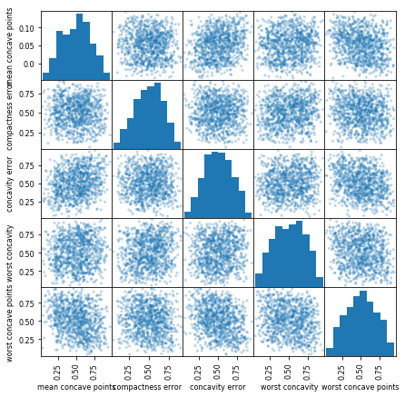

```
Epoch 11 / 200 completed. Wasserstein metric: 0.00005841
Epoch 21 / 200 completed. Wasserstein metric: 0.00018321
Epoch 31 / 200 completed. Wasserstein metric: 0.00037406
Epoch 41 / 200 completed. Wasserstein metric: 0.00037261
Epoch 51 / 200 completed. Wasserstein metric: 0.00031721
```

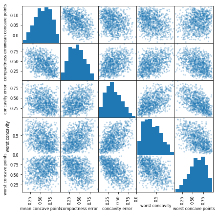

```
Epoch 61 / 200 completed. Wasserstein metric: 0.00016014
Epoch 71 / 200 completed. Wasserstein metric: 0.00015246
Epoch 81 / 200 completed. Wasserstein metric: 0.00007968
Epoch 91 / 200 completed. Wasserstein metric: 0.00005282
Epoch 101 / 200 completed. Wasserstein metric: 0.00002174
```

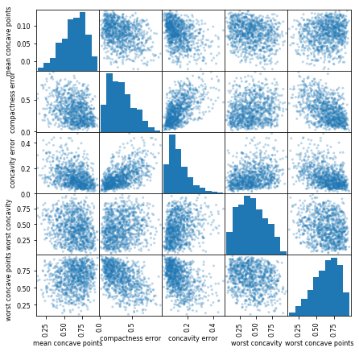

```
Epoch 111 / 200 completed. Wasserstein metric: -0.00002185
Epoch 121 / 200 completed. Wasserstein metric: -0.00000125
Epoch 131 / 200 completed. Wasserstein metric: -0.00000239
Epoch 141 / 200 completed. Wasserstein metric: -0.00000056
Epoch 151 / 200 completed. Wasserstein metric: 0.00000016
```

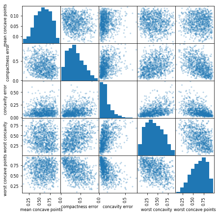

```
Epoch 161 / 200 completed. Wasserstein metric: -0.00000571
Epoch 171 / 200 completed. Wasserstein metric: 0.00000024
Epoch 181 / 200 completed. Wasserstein metric: 0.00000162
Epoch 191 / 200 completed. Wasserstein metric: -0.00000331
```

```python
generator = Generator(n_inp, NOISE_DIM)
critic = Critic(n_inp)

generator_optimizer = tf.keras.optimizers.RMSprop(learning_rate)
critic_optimizer = tf.keras.optimizers.RMSprop(learning_rate)

epoch_wasserstein = []

for epoch in range(epochs):
    batch_idx = 0
    batch_wasserstein = 0

    for batch in train_dataset:
        wasserstein = train_step(batch, generator, critic, NOISE_DIM,
                                         generator_optimizer,
                                         critic_optimizer)
        epoch_wasserstein.append(wasserstein)
        batch_wasserstein += wasserstein
        batch_idx += 1

    batch_wasserstein = batch_wasserstein / batch_idx

    if epoch % 10 == 0:
        print("Epoch %d / %d completed. Wasserstein metric: %.8f" % (epoch + 1, epochs, batch_wasserstein))

    if epoch % 50 == 0:
        fake_data = generator(tf.random.normal([1000, NOISE_DIM]))
        x = pd.DataFrame(data = np.array(fake_data), columns=["mean concave points","compactness error","concavity error","worst concavity","worst concave points"])
        plot_matrix(x, (7,7), 8)
        plt.show()
```

Now let's generate some fake data and plot its pariwise distributions.

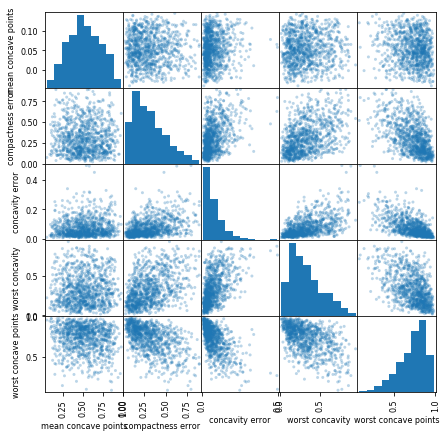

```python
fake_data = generator(tf.random.normal([1000, NOISE_DIM]))
x = pd.DataFrame(data = np.array(fake_data), columns=["mean concave points","compactness error","concavity error","worst concavity","worst concave points"])
plot_matrix(x, (7,7), 8)
```

```python
malDF = x
malDF["target"]=np.repeat(0,len(malDF))
malDF.head()
```

|  | mean concave points | compactness error | concavity error | worst concavity | worst concave points | target |
| --- | --- | --- | --- | --- | --- | --- |
| 0 | 0.564042 | 0.208080 | 0.176099 | 0.530036 | 0.246809 | 0 |
| 1 | 0.640817 | 0.261138 | 0.151743 | 0.642348 | 0.637085 | 0 |
| 2 | 0.609386 | 0.267884 | 0.135262 | 0.742036 | 0.252282 | 0 |
| 3 | 0.594334 | 0.516459 | 0.169841 | 0.735008 | 0.604676 | 0 |
| 4 | 0.391139 | 0.225536 | 0.036406 | 0.126119 | 0.618062 | 0 |

```python
mergedDF = pd.concat([malDF, benDF], sort=False).sample(frac=1).reset_index(drop=True)
mergedDF.head()
```

|  | mean concave points | compactness error | concavity error | worst concavity | worst concave points | target |
| --- | --- | --- | --- | --- | --- | --- |
| 0 | 0.126513 | 0.144967 | 0.029242 | 0.061565 | 0.237023 | 1.0 |
| 1 | 0.769834 | 0.156586 | 0.063054 | 0.163193 | 0.780043 | 0.0 |
| 2 | 0.344269 | 0.271487 | 0.025300 | 0.052004 | 0.930520 | 0.0 |
| 3 | 0.661596 | 0.383924 | 0.057484 | 0.425927 | 0.697976 | 0.0 |
| 4 | 0.308612 | 0.305459 | 0.025807 | 0.430531 | 0.656219 | 0.0 |

We can now plot the enriched dataset colour-coded for the two classes.

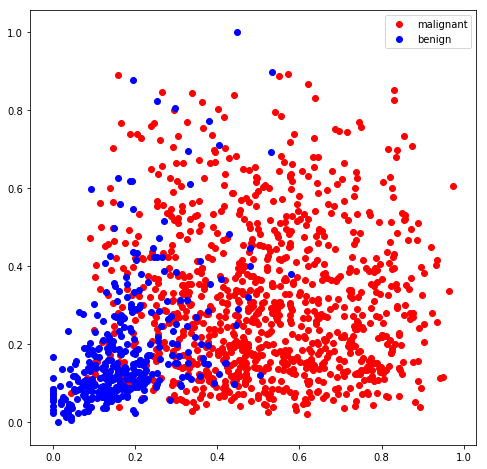

```python
fig,ax = plt.subplots(figsize=(8,8))
ax.scatter(malDF.iloc[:,0], malDF.iloc[:,1], c="red", label="malignant")
ax.scatter(benDF.iloc[:,0], benDF.iloc[:,1], c="blue", label="benign")
ax.legend()
plt.show()
```